Review Article

Tissue Engineering of the BladderdReality or Myth?

A Systematic Review

Marije Sloff,*,† Vasileios Simaioforidis,* Rob de Vries, Egbert Oosterwijk

and Wout Feitz

From the Department of Urology, Radboud Institute for Molecular Life Sciences and Systematic Review Center for Laboratory

Animal Experimentation, Central Animal Facility (RdeV), Radboud University Medical Center, Nijmegen, The Netherlands

Purpose: We systematically reviewed preclinical studies in the literature to

evaluate the potential of tissue engineering of the bladder. Study outcomes were

compared to the available clinical evidence to assess the feasibility of tissue

engineering for future clinical use.

Materials and Methods: Preclinical studies of tissue engineering for bladder

augmentation were identiﬁed through a systematic search of PubMed and

Embase� from January 1, 1980 to January 1, 2014. Primary studies in English

were included if bladder reconstruction after partial cystectomy was performed

using a tissue engineered biomaterial in any animal species, with cystometric

bladder capacity as an outcome measure. Outcomes were compared to clinical

studies available at http://www.clinicaltrials.gov and published clinical studies.

Results: A total of 28 preclinical studies are included, demonstrating remarkable

heterogeneity in study characteristics and design. Studies in which preoperative

bladder volumes were compared to postoperative volumes were considered

the most clinically relevant (18 studies). Bladder augmentation through tissue

engineering resulted in a normal bladder volume in healthy animals, with the

inﬂuence of a cellular component being negligible. Furthermore, experiments in

large animal models (pigs and dogs) approximated the desired bladder volume

more accurately than in smaller species. The initial clinical experience was

based on seemingly predictive healthy animal models with a promising outcome.

Unfortunately these results were not substantiated in all clinical trials,

revealing dissimilar outcomes in different clinical/disease backgrounds. Thus,

the translational predictability of a model using healthy animals might be

questioned.

Conclusions: Through this systematic approach we present an unbiased over-

view of all published preclinical studies investigating the effect of bladder tissue

engineering on cystometric bladder capacity. Preclinical research in healthy

animals appears to show the feasibility of bladder augmentation by tissue en-

gineering. However, in view of the disappointing clinical results based on healthy

animal models new approaches should also be evaluated in preclinical models

using dysfunctional/diseased bladders. This endeavor may aid in the develop-

ment of clinically applicable tissue engineered bladder augmentation with

satisfactory long-term outcome.

Key Words: meta-analysis; models, animal; reconstructive surgical

procedures; tissue engineering; urinary bladder

Abbreviations

and Acronyms

PLGA ¼ poly(lactic-co-glycolic)

acid

SIS ¼ small intestinal submucosa

SMC ¼ smooth muscle cell

UC ¼ urothelial cell

Accepted for publication March 26, 2014.

* Equal study contribution.

† Correspondence: Department of Urologye

Experimental Urology 267, Radboud University

Medical Center, Geert Grooteplein 26/28, PO Box

9101, 6525 GA Nijmegen, The Netherlands

(telephone: 31-24-3610502; FAX: 31-24-3541222;

e-mail: marije.sloff@radboudumc.nl).

See Editorial on page 1021.

0022-5347/14/1924-1035/0

THE JOURNAL OF UROLOGY<sup>®</sup>

© 2014 by AMERICAN UROLOGICAL ASSOCIATION EDUCATION AND RESEARCH, INC.

http://dx.doi.org/10.1016/j.juro.2014.03.116

Vol. 192, 1035-1042, October 2014

Printed in U.S.A.

www.jurology.com j 1035

DECREASED bladder compliance and/or capacity due

to bladder dysfunction, eg neurogenic bladder, may

require bladder augmentation. Current surgical

techniques mainly involve the use of gastrointes-

tinal tissues. Due to the physical properties of the

tissue, complications may develop, including meta-

bolic disorders, bladder perforation, stone forma-

tion, infections and hematuria-dysuria syndrome,

as well as cancer due to metaplasia.<sup>1,2</sup>To avoid

these complications and extensive operations, new

therapeutic alternatives are needed. Tissue engi-

neering approaches could offer innovative options

for bladder reconstruction by use of biomaterials

supplemented with cells and/or growth factors. This

application might result in the regeneration of

bladder tissue or in the construction of a neo-

bladder, which has been pioneered by Atala et al.<sup>3</sup>

In this systematic review we present a compre-

hensive overview of the current literature regarding

preclinical

bladder

tissue

engineering,

with

quantitative and unbiased comparison of study<sup>a</sup>

outcomes. Cystometric bladder volume was used as

an outcome measure to assess the effect of tissue

engineering since bladder volume is of paramount

importance in the clinical situation. We also discuss

the available information concerning clinical expe-

rience with tissue engineered bladders.

MATERIALS AND METHODS

Search Strategy

We systematically searched PubMed and Embase (OvidSP)

through

January

1,

2014

to

systematically

identify

preclinical studies of tissue engineering and bladder

reconstruction.<sup>4,5</sup>Synonyms for tissue engineering were

combined with synonyms for bladder reconstruction using

MeSH (PubMed) and Emtree terms (Embase), as well as

free text words from titles or abstracts ([tiab] or /ti,ab,

supplementary ﬁg. 1, http://jurology.com/). Subsequently

results were ﬁltered for animal studies using previously

designed animal ﬁlters.<sup>6,7</sup>The bibliographies of included

series and relevant reviews were screened for any missing

studies. Furthermore, clinical trials regarding this subject

were manually identiﬁed using www.clinicaltrials.gov

and PubMed.

Study Inclusion

After removal of duplicates and triplicates in EndNote,

X5 (Thomson Reuters, Philadelphia, Pennsylvania) 2 re-

viewers (VS, MS) excluded studies based on titles that

clearly were not related to the subject. Next, they inde-

pendently screened the abstracts of the remaining studies

using Early Review Organizing Software (http://www.

eros-systematic-review.org), excluding 1) review articles,

2) studies in which bladder reconstruction was not per-

formed after partial cystectomy, 3) studies in which tissue

engineered biomaterial was not used and 4) studies

without an animal model. Review articles were labeled

but not included for further analysis. Thereafter, the

eligibility of studies was investigated by a full text

assessment. Studies were also excluded if they 1) were not

an original article (eg conference abstracts, editorial

comments), 2) were not published after 1980, 3) had no

cystometry data available and lacked mean, standard

deviation/standard error and number, 4) had no disease

consensus was reached.

Data Extraction

Table 1 outlines the general characteristics and outcomes

of the included studies. The quality of the studies was

assessed

using

a

previously

designed

questionnaire

(supplementary ﬁg. 2, http://jurology.com/). Cystometric

data on bladder volume (mean � SD bladder capacity,

number of animals) was used for meta-analyses. In case of

more than 1 experimental group or time point the most

successful group, as indicated by the authors, at the end

point was used in the analyses. The parameter of bladder

volume was chosen because it has the greatest clinical

signiﬁcance in bladder augmentation procedures, which

aim at restoring bladder volume and protecting the upper

urinary tract.

Meta-Analyses

Meta-analyses were performed for mean bladder volumes.

Due to large differences in absolute bladder volumes

between species, standardized mean differences were

calculated for the individual studies.<sup>8</sup>Since different

species and biomaterials were used, considerable hetero-

geneity was expected. Therefore, studies were organized

according to study type (I to IV) and analyzed using a

random effects model to calculate overall effect size, 95% CI

and I<sup>2</sup>(measure of statistical heterogeneity). Type I studies

compared experimental bladder volumes with volumes of

healthy control animals, type II compared preoperative and

postoperative measurements in the same animals, type III

compared sham operated animals to outcome (although

the deﬁnition of sham operated was unclear) and type IV

compared augmented animals to nonaugmented animals

(primary closure) after partial cystectomy. Further sub-

group analyses were only performed with type II studies,

and included animal species and construct type (with or

without cells). ReviewManager,� version 5.2 was used to

create forest plots and perform meta-analyses.

RESULTS

Study Inclusion and Characteristics

Figure 1 outlines study inclusion and exclusion

criteria. A total of 28 articles were included for data

synthesis and meta-analysis.<sup>9</sup><sup>e</sup><sup>36</sup>Exclusions during

full text assessment were mainly related to incom-

plete or missing cystometry measurements. No

additional references were found in the bibliogra-

phies of the included studies or relevant reviews.

Three articles were excluded from further analysis

since either the control group was represented as

100% without any SD or the experimental group

consisted of only 1 subject.<sup>37</sup><sup>e</sup><sup>39</sup>

1036

TISSUE ENGINEERING OF BLADDER

The type of control group varied across studies,

which were categorized into 4 types (table 1).

The studies demonstrate a high degree of hetero-

geneity with respect to animal species, extent of

cystectomy, followup, biomaterials, and use of cells

and growth factors.

Tissue Engineering for Bladder Reconstruction

The quality of the included studies was sufﬁcient

(supplementary ﬁg. 2), specifying the most important

details on animal number, species, biomaterial,

extent of cystectomy and length of followup. Pooling

the effect sizes of all study types was not possible

because the use of different control groups required

different interpretation of the results (table 2, ﬁg. 2).

Nevertheless, heterogeneity (I<sup>2</sup>) was still high for

individual study types, suggesting that besides con-

trol groups, other factors including animal species,

biomaterials and surgical techniques may have a role

in causing study type heterogeneity.

Meta-analyses for types I and II studies did not

reveal a signiﬁcant difference in bladder volumes

between controls, either healthy or preoperative,

and experimental animals. In the type III studies

the sham control group was undeﬁned but no sig-

niﬁcant difference was observed. By comparison,

for type IV studies a signiﬁcant effect was found, in

that experimental animals presented with a larger

bladder volume than control animals in which par-

tial cystectomy was performed without augmenta-

tion (ﬁg. 2).

Subgroup Analyses

Bladder

augmentation

is

performed

to

restore

normal

bladder

volumes.

In

type

II

studies

Table 1. Study characteristics

References

Study

Type

Animals

Cystectomy

Followup

(mos)

Material

Models (stock/strain)

Sex

Age

Wt

Mauney et al<sup>9</sup>

I

Mice (CD-1�)

6 Wks

1 cm<sup>2</sup>

2.5

Silk

Adamowicz et al<sup>10</sup>

I

Rats (Wistar)

Male

0.7 cm<sup>2</sup>

Amniotic membrane þ bone

marrow stem cells

Lepper et al<sup>11</sup>

I

Rabbits

Male

3.1e4.2 Kg

16 cm<sup>2</sup>

3

Collagen

Horst et al<sup>12</sup>

II

Rats (Lewis)

Female

200 Gm

Partial

2

PLGA/bladder acellular matrix

Jack et al<sup>13</sup>

II

Rats (rnu)

Female

200e250 Gm

50%

3

PLGA þ adipose derived stem cells

Wefer et al<sup>14</sup>

II

Rats (Sprague Dawley)

Female

3 Mos

50%

3

Bladder acellular matrix

Yang et al<sup>15</sup>

II

Rabbits (New Zealand)

Female

2.5e3.5 Kg

40%e50%

2

Bladder acellular matrix

Zhu et al<sup>16</sup>

II

Rabbits (New Zealand)

Male

40%e60%

6

Bladder acellular matrix þ adipose

derived stem cells

Zhu et al<sup>17</sup>

II

Rabbits (New Zealand)

60%e70%

6

Bladder acellular matrix

Paterson et al<sup>18</sup>

II

Minipigs (Yucatan)

53e76 Lbs

48 cm<sup>2</sup>

12

SIS

Portis et al<sup>19</sup>

II

Minipigs (Yucatan)

Female

9 cm<sup>2</sup>

3

SIS

Jayo et al<sup>20</sup>

II

Dogs (mongrel)

Male þ female

80%

24

Polyglycolic acid þ SMCs/UCs

Jayo et al<sup>21</sup>

II

Dogs (mongrel)

Male þ female

75%

9

PLGA þ SMCs/UCs

Kambic et al<sup>22</sup>

II

Dogs

25 Kg

50%

4

Pericardium

Kropp et al<sup>23</sup>

II

Dogs (beagle)

Male

11e13 Kg

35%e45%

14

SIS

Roth et al<sup>24</sup>

II

Dogs (beagle)

Male

13.9 Kg

40%

2.5

SIS þ nanoparticles

Sievert et al<sup>25</sup>

II

Dogs (mongrel)

Female

1 Yr

50%

7

Bladder acellular matrix

Zhang et al<sup>26</sup>

II

Dogs (beagle)

Male

12e13 Kg

90%

9

SIS þ SMCs/UCs

Caione et al<sup>27</sup>

II

Pigs (Landrace)

Female

2 Mos

Partial

3

SIS

Hattori et al<sup>28</sup>

II

Pigs

Male

15e18 Kg

50%

3

Collagen

Sharma et al<sup>29</sup>

II

Monkeys (baboon)

Female

18e20 Kg

40%e50%

2.5

SIS þ mesenchymal stem cells

Chen et al<sup>30</sup>

III

Rats (Sprague Dawley)

Male

300 Gm

50%

3

Collagen þ basic fibroblast

growth factor

Kajbafzadeh et al<sup>31</sup>

III

Rats (Sprague Dawley)

Male

250e270 Gm

50%

3

Bladder acellular matrix

Yu et al<sup>32</sup>

III

Rats (Sprague Dawley)

Male

400e450 Gm

50%

2

Collagen-coated poly

(epsilon-caprolactone)

Mimura et al<sup>33</sup>

IV

Rats (Sprague Dawley)

Female

337.9 � 30.2 Gm

50%

2

Pericardium

Piechota et al<sup>34</sup>

IV

Rats (Sprague Dawley)

Male þ female

50%

4

Bladder acellular matrix

Piechota et al<sup>35</sup>

IV

Rats (Sprague Dawley)

Male þ female

3 Mos

50%

4

Bladder acellular matrix

Koiso et al<sup>36</sup>

IV

Rabbits

Female

2e2.5 Kg

50%

12

Poly(e-benzyloxycarbonyl-l-lysine)

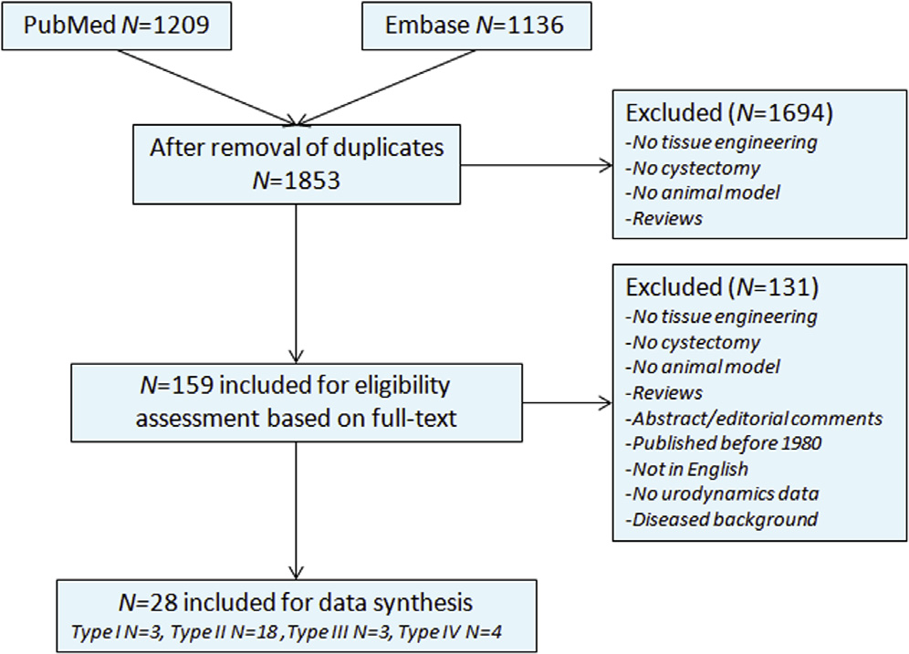

Figure 1. Flowchart of study inclusion criteria

TISSUE ENGINEERING OF BLADDER

1037

preoperative values were compared to postoperative

values, an approach also used clinically. Thus, this

study type comes closest to the clinical situation,

and, therefore, was used for subgroup analysis.

Subgroup analyses were performed for different

animal models (ﬁg. 3) and construct types (cellular

and acellular, ﬁg. 4). Subgroup analysis showed that

bladder reconstruction in rats resulted in a signiﬁ-

cantly larger bladder volume, in contrast to the

overall effect found for all type II studies (ﬁg. 3, A).

This effect was not restricted to type II studies. In

all of the rat studies bladder volumes increased

regardless

of

type

of

control

(2.77,

95%

CI

0.78e4.77). In the 3 rabbit studies the bladder

volume was negatively affected and included a large

95% CI. This result was mainly due to ﬁndings of

Zhu et al (ﬁg. 3, B).<sup>16,17</sup>Large animal models were

limited to pigs and dogs, both of which correctly

approximate the desired effect, as observed in the

combined type II studies (ﬁg. 3, C and D). Use of

either species results in an I<sup>2</sup>of less than 75%,

which is less than in the combined type II studies.

Dogs demonstrated a narrower 95% CI, with an

effect closer to the desired type II effect than was

observed in pigs.

We also investigated the effect of (pre-)seeding

biomaterials

on

bladder

volume

and

compared

cellular constructs with acellular constructs (ﬁg. 4).

No signiﬁcant difference was observed between the

2 subgroups (large overlap in 95% CI). A slight shift

toward a smaller bladder volume was observed for

the cellular constructs.

DISCUSSION

Bladder Tissue Engineering

Developments in preclinical research for bladder

reconstruction have resulted in 2 clinical trials in

the last decade.<sup>3,40</sup>We systematically searched the

current literature to identify all preclinical research

regarding tissue engineering for bladder recon-

struction to investigate the feasibility of a tissue

engineered bladder as a potential new therapy.

Using predeﬁned criteria, including cystometric

bladder capacity outcome, 28 studies were included.

Bladder

augmentation

aims

to restore

bladder

volume and thereby protect the upper urinary tract.

Thus, this parameter has the highest clinical sig-

niﬁcance, and, therefore, was chosen to be evalu-

ated. The heterogeneity between these 28 studies

was high, in that different species and biomaterials

were used.

Based on control groups, the 28 studies were

divided into 4 categories, ie healthy controls (type I),

preoperative status as control (II), undeﬁned sham

operation (III) and partial cystectomy with primary

closure (IV). Every type of control has speciﬁc

advantages and disadvantages. In type II studies

the approach is analogous to the clinical case, where

increased bladder capacity is the primary goal of

surgery. Therefore, type II studies were used for

further subgroup analysis.

Bladder capacity was used to compare the out-

comes of the different studies and predict the

success of a clinical tissue engineering approach. In

animal models bladder volume should ultimately

return to normal values after partial cystectomy

and augmentation, resulting in a nonsigniﬁcant

difference

between

healthy

and

experimental

groups. The latter was true for type II studies,

where animals served as their own controls. This

ﬁnding suggests that the same bladder capacity can

be achieved after partial cystectomy followed by

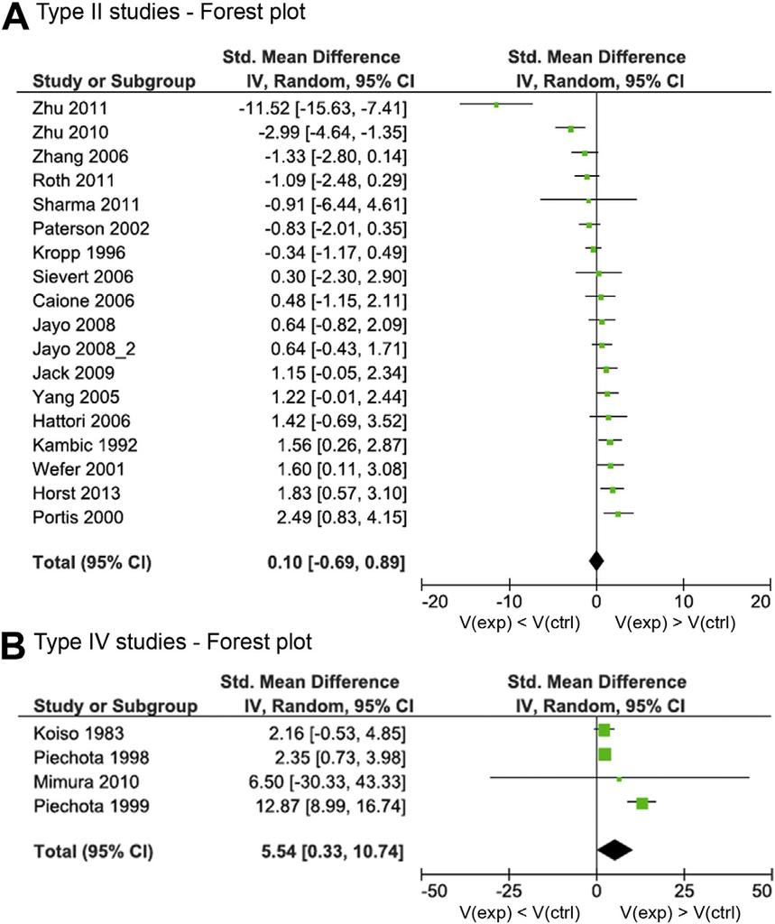

Figure 2. A, forest plot for type II studies. B, forest plot for type

IV studies. ctrl, control. exp, experimental model. V, volume.

Table 2. Meta-analyses by study type

Study Type

No. Studies

SMD (95% CI)

I<sup>2</sup>(%)

I

3

1.38 (�2.26, 5.03)

90

II

18

0.10 (�0.69, 0.89)

80

III

3

1.06 (�0.93, 3.04)

81

IV

4

5.54 (0.33, 10.74)

88

Study types I, II and III showed nonsignificant difference between control and

experimental groups. Study type IV showed significant difference between control

and experimental groups.

1038

TISSUE ENGINEERING OF BLADDER

repair with a biomaterial, indicating the feasibility

of tissue engineering for bladder augmentation.

However, the variation within this study type was

quite high (I<sup>2</sup>), with deviations in positive and

negative directions. Most likely this result is the

corollary of inclusion of different animal species and

biomaterials. In type IV studies the bladder volume

was not restored to the original volume after partial

cystectomy and primary closure of the defect.

Comparison of type II and type IV studies indicates

that the restoration of bladder capacity is indeed the

consequence of the tissue engineering approach.

Cells and Bladder Volume

The effect of seeding/preseeding tissue engineered

constructs in bladder reconstruction remains a

subject of discussion within the ﬁeld of tissue engi-

neering. Although different groups have reported

the advantageous effect of a cellular component, we

found that in the evaluated animal models a cellular

component does not result in a better bladder vol-

ume than acellular constructs.<sup>16,41</sup>Acellular and

cellular constructs resulted in similar ﬁnal bladder

volumes

after

augmentation.

In

fact,

a

slight

decrease in bladder volume was observed in the

group with cellular constructs.

In this review we focused on bladder volume as

the most important parameter. Although cells do

not seem to aid in the preservation of bladder

capacity, they might be necessary for long-term

tissue regeneration. Whether cell seeding has a

favorable effect on other essential parameters such

as voiding patterns, bladder compliance and bladder

histology is unclear, and is beyond the scope of this

review as these parameters were not included. Only

healthy animals were included in this review, and,

therefore, only healthy cells were used for cell

seeding. Other cell sources might be considered

to achieve a clinically satisfactory outcome when

cell seeded scaffolds are used. Alternatively a smart

acellular scaffold might be considered.

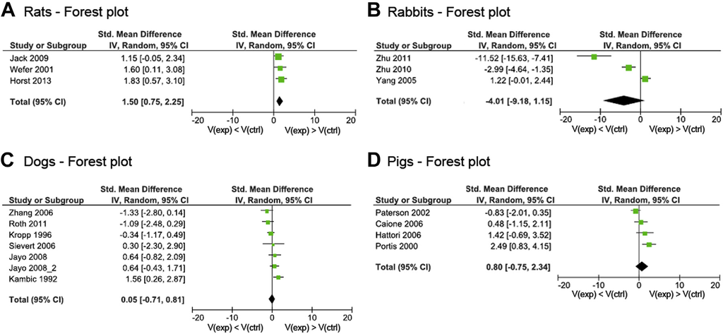

Figure 3. Forest plots for type II studies. A, rat studies (I<sup>2</sup>0%). B, rabbit studies (I<sup>2</sup>95%). C, dog studies (I<sup>2</sup>57%). D, pig studies (I<sup>2</sup>73%).

ctrl, control. exp, experimental model. V, volume.

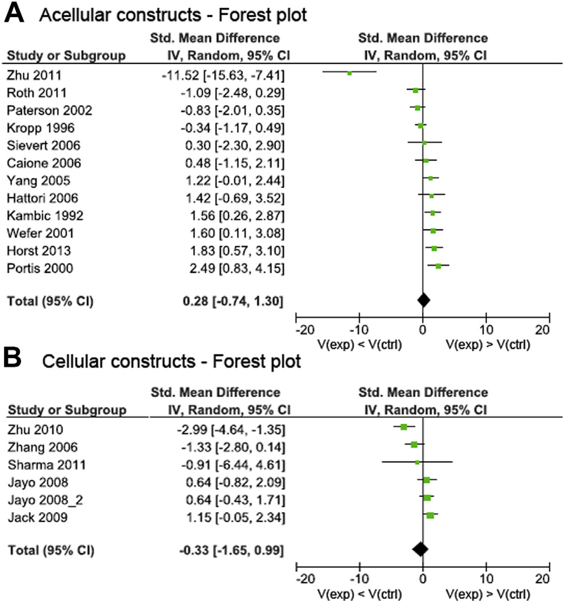

Figure 4. Forest plots for type II studies. A, acellular constructs

(I<sup>2</sup>83%). B, cellular constructs (I<sup>2</sup>77%). ctrl, control. exp,

experimental model. V, volume.

TISSUE ENGINEERING OF BLADDER

1039

Animal Models

Besides indicating the effectiveness of a tissue en-

gineering approach, we aimed to identify an animal

model that would adequately predict the behavior of

tissue engineered constructs for bladder augmen-

tation. Small animal species (such as rats and

rabbits) do not appear to approximate the desired

effect (type II). In rats bladder tissue engineering

leads to a larger bladder volume after treatment

regardless of study type (I to IV). This ﬁnding may

be explained by the high regenerative capacity of

the rat bladder, in that even after subtotal cys-

tectomy without augmentation the bladder volume

recovers completely.<sup>42</sup>The rabbit model exhibits

a heterogeneous pattern of outcomes regarding

bladder volume (ﬁg. 3, B). Formation of calciﬁca-

tions, a known drawback of this model,<sup>43</sup>may

explain the variation but was reported in only 1 of 3

studies (Zhu et al,<sup>17</sup>supplementary ﬁg. 2). Type II

studies in large animals are limited to dogs and

pigs, and both appear to be representative for

studying bladder tissue engineering since normal

bladder capacities are reached after augmentation.

However, the use of dogs in experimental research

remains subject to ethical discussion.

Clinical Trials

In the ﬁrst clinical study concerning bladder tissue

engineering

a

seeded

collagen

or

composite

collagen-polyglycolic acid scaffold was used for

augmentation cystoplasty in young patients with

myelomeningocele.<sup>3</sup>This phase I study was based

on preclinical experience in dogs.<sup>37</sup>The outcomes

did not reveal any cytotoxicity and indicated the

safety of this approach, suggesting a promising

future for this technique. Further research in 2 dog

studies supported these ﬁndings, with bladder ca-

pacity being regained at 3 to 6 months after im-

plantation of the construct.<sup>20,21</sup>

From the clinical and preclinical data it appears

that omental wrapping and bladder cycling are

crucial to success as they result in larger post-

operative bladder capacities. No major complica-

tions were reported in the preclinical studies.

Unfortunately the results were disappointing in a

phase II clinical trial that included 10 patients with

neuropathic bladder due to spina biﬁda. A seeded

PLGA copolymer scaffold adapted to the individual

size was implanted onto the bladder. Many patients

experienced multiple adverse events, and most had

undergone conversion to a traditional ileocysto-

plasty at publication of the study.<sup>40</sup>Although the

phase I and phase II trials were comparable in

design, using the same clinical background, cell

types, omental wrapping and bladder cycling tech-

niques, the promising efﬁcacy of the phase I study

could not be substantiated in the phase II study.

In contrast, repair of exstrophic bladders (a

different disease status) with SIS alone in 5 patients

5 to 17 years old showed a more favorable outcome.<sup>44</sup>

The authors demonstrated the development of a

bladder wall covered with a multilayered urothelium

fully covering the lamina propria, similar to normal

urothelium. The smooth muscle wall was less

developed compared to the native detrusor wall, and

long-term continence was not achieved. Therefore,

one might question the predictive value of preclinical

experiments in healthy large animals.<sup>27,40</sup>

Diseased Animal Models

The different outcomes of the phase II studies of

patients with neuropathic bladder may be explained

by the disease status of the bladder. The harvested

bladder material as a cell source or the regenerative

capacity of the bladder itself might have inﬂuenced

the regeneration process. These factors may have

caused the unsatisfactory clinical outcome, whereas

the

preclinical

studies

suggested

a

favorable

outcome. It is unclear whether the favorable outcome

in the exstrophic bladder scenario was the result of

the more potent regenerative capacity in young pa-

tients or the superior quality of the urothelium of

exstrophic compared to neuropathic bladders.

Although the number of studies in diseased ani-

mals is low, the exclusion of these studies might

have biased our extrapolation of the preclinical

neering of a diseased bladder were identiﬁed. The

rat studies revealed a positive outcome for tissue

engineered

bladder

augmentation

in

a

disease

model.<sup>45,46</sup>However, these results have to be viewed

with

caution

given

the

inherent

regenerative

capacity of the rat bladder, which might have

inﬂuenced the outcome positively. Bladder aug-

mentation after outlet obstruction in a large animal

model was less effective than in healthy animals,

which might indicate the negative effect of disease

status on bladder regeneration.<sup>47</sup>Furthermore, age

might inﬂuence the regenerative capacity of the

bladder. In newborn lambs with bladder exstrophy

the regeneration pattern in diseased and normal

bladders was similar.<sup>48</sup>However, the regenerative

capacity in newborns is more potent than in adults,

which may have obscured abnormalities that can

occur when older animals are studied. This factor

might explain why a slightly better outcome was

observed in the clinical trial of patients with

bladder exstrophy.

The

evidence

in

diseased

animal

models,

although limited, suggests that the disease status

might inﬂuence the regenerative capacity of the

subject. Indeed, in vitro analysis showed that the

proliferation and differentiation capacity of isolated

UCs

and

SMCs

from

diseased

patients

was

1040

TISSUE ENGINEERING OF BLADDER

diminished and altered compared to healthy in-

dividuals.<sup>49,50</sup>The altered proliferation capacity

observed in 2 patients in the phase II clinical study

suggests that this factor may have had a role in the

clinical outcome and may explain the disappointing

results. Collectively the evidence appears to imply

that

disease

status

inﬂuences

the

outcome

of

bladder tissue engineering.

Study Limitations and Recommendations

A systematic review in combination with a meta-

analysis is an adequate approach to objectively

identify and analyze studies within a certain ﬁeld of

research. Using predeﬁned selection criteria is

objective but might result in the exclusion of indi-

rectly relevant and high quality articles, which is

a drawback of this approach. The key parameter

of this systematic review was bladder capacity,

although

other

parameters

including

bladder

compliance, voiding patterns and tissue regenera-

tion using histological and morphological analyses

were of equal importance. Furthermore, variables

including biomaterials, growth factors and extent of

cystectomy

may

inﬂuence

study

outcomes.

To

further investigate the efﬁcacy of this approach,

these parameters need to be addressed to gain

more insight into bladder tissue engineering. As

indicated, a successful preclinical outcome does not

necessarily translate into a successful clinical trial.

Therefore, it is important to design a preclinical

study using the best predictive model available with

an adequate disease background to mimic the clin-

ical situation. For bladder tissue engineering large

animals with diseased bladders appear to represent

the best possible study model.

CONCLUSIONS

The preclinical evidence suggests that tissue engi-

neered bladder augmentation in healthy animals

results in normal bladder capacity on followup. The

advantageous effect of cell seeding with respect to

bladder volume was not evident in animal studies

from the evaluated literature. Large animals such

as pigs and dogs appeared to be the best predictive

models, although the translational value of healthy

animal models appears to be questionable since

the regenerative capacity might be overestimated

compared to the clinical setting. Tissue engineering

of the bladder might become a reality in the future.

However, to correctly predict the effect of tissue

engineering

for

bladder

augmentation,

animal

models with dysfunctional bladders should also

be evaluated.

REFERENCES

1. Kaefer M, Hendren WH, Bauer SB et al: Reser-

voir calculi: a comparison of reservoirs con-

structed

from

stomach

and

other

enteric

segments. J Urol 1998; 160: 2187.

2. Gilbert SM and Hensle TW: Metabolic conse-

quences and long-term complications of entero-

cystoplasty in children: a review. J Urol 2005;

173: 1080.

3. Atala A, Bauer SB, Soker S et al: Tissue-

engineered autologous bladders for patients

needing cystoplasty. Lancet 2006; 367: 1241.

4. de Vries RB, Buma P, Leenaars M et al: Reducing

the number of laboratory animals used in tissue

engineering research by restricting the variety of

animal models. Articular cartilage tissue engi-

neering as a case study. Tissue Eng Part B Rev

2012; 18: 427.

5. Leenaars M, Hooijmans CR, van Veggel N

et al: A step-by-step guide to systematically

identify all relevant animal studies. Lab Anim

2012; 46: 24.

6. de Vries RB, Hooijmans CR, Tillema A et al: A

search filter for increasing the retrieval of animal

studies in Embase. Lab Anim 2011; 45: 268.

7. Hooijmans CR, Tillema A, Leenaars M et al:

Enhancing search efficiency by means of a

search filter for finding all studies on animal

experimentation in PubMed. Lab Anim 2010;

44: 170.

8. Higgins JPT and Green S: Cochrane Handbook

for Systematic Reviews of Interventions, version

5.1.0 (updated March 2011). The Cochrane

Collaboration 2011. Available at www.handbook.

cochrane.org. Accessed March 26, 2014.

9. Mauney JR, Cannon GM, Lovett ML et al:

Evaluation of gel spun silk-based biomaterials

in a murine model of bladder augmentation.

Biomaterials 2010; 32: 808.

10. Adamowicz J, Juszczak K, Bajek A et al:

Morphological and urodynamic evaluation of

urinary

bladder

wall

regeneration:

muscles

guarantee contraction but not proper functiond

a rat model research study. Transplant Proc 2012;

44: 1429.

11. Lepper FG, Ramos TM, Trindade Filho JC et al:

Bladder augmentation in rabbits with anionic

collagen membrane, with or without urothelial

preservation. Cystometric and histologic evalua-

tion. Int Braz J Urol 2002; 28: 464.

12. Horst M, Madduri S, Milleret V et al: A bilayered

hybrid

microfibrous

PLGAdacellular

matrix

scaffold for hollow organ tissue engineering.

Biomaterials 2013; 34: 1537.

13. Jack GS, Zhang R, Lee M et al: Urinary bladder

smooth muscle engineered from adipose stem

cells and a three dimensional synthetic com-

posite. Biomaterials 2009; 30: 3259.

14. Wefer J, Sievert KD, Schlote N et al: Time

dependent smooth muscle regeneration and

maturation in a bladder acellular matrix graft:

histological studies and in vivo functional eval-

uation. J Urol 2001; 165: 1755.

15. Yang SX, Shen FJ, Hu YF et al: Experimental

bladder defect in rabbit repaired with homolo-

gous bladder extracellular matrix graft. Chin Med

J (Engl) 2005; 118: 957.

16. Zhu WD, Xu YM, Feng C et al: Bladder recon-

struction with adipose-derived stem cell-seeded

bladder

acellular

matrix

grafts

improves

morphology composition. World J Urol 2010; 28:

493.

17. Zhu WD, Xu YM, Feng C et al: Different bladder

defects reconstructed with bladder acellular

matrix grafts in a rabbit model. Urologe A 2011;

50: 1420.

18. Paterson RF, Lifshitz DA, Beck SD et al: Multi-

layered small intestinal submucosa is inferior to

autologous

bowel

for

laparoscopic

bladder

augmentation. J Urol 2002; 168: 2253.

TISSUE ENGINEERING OF BLADDER

1041

19. Portis AJ, Elbahnasy AM, Shalhav AL et al:

Laparoscopic

augmentation

cystoplasty

with

different biodegradable grafts in an animal

model. J Urol 2000; 164: 1405.

20. Jayo MJ, Jain D, Ludlow JW et al: Long-term

durability, tissue regeneration and neo-organ

growth during skeletal maturation with a neo-

bladder augmentation construct. Regen Med

2008; 3: 671.

21. Jayo MJ, Jain D, Wagner BJ et al: Early cellular

and stromal responses in regeneration versus

repair of a mammalian bladder using autologous

cell and biodegradable scaffold technologies.

J Urol 2008; 180: 392.

22. Kambic H, Kay R, Chen JF et al: Biodegradable

pericardial implants for bladder augmentation:

a 2.5-year study in dogs. J Urol 1992; 148: 539.

23. Kropp BP, Rippy MK, Badylak SF et al: Regen-

erative urinary bladder augmentation using small

intestinal submucosa: urodynamic and histo-

pathologic

assessment

in

long-term

canine

bladder augmentations. J Urol 1996; 155: 2098.

24. Roth

CC,

Mondalek

FG,

Kibar

Y

et

al:

Bladder regeneration in a canine model using

hyaluronic acid-poly(lactic-co-glycolic-acid) nano-

particle modified porcine small intestinal sub-

mucosa. BJU Int 2011; 108: 148.

25. Sievert KD, Fandel T, Wefer J et al: Collagen I:III

ratio in canine heterologous bladder acellular

matrix grafts. World J Urol 2006; 24: 101.

26. Zhang Y, Frimberger D, Cheng EY et al: Chal-

lenges in a larger bladder replacement with

cell-seeded and unseeded small intestinal sub-

mucosa grafts in a subtotal cystectomy model.

BJU Int 2006; 98: 1100.

27. Caione P, Capozza N, Zavaglia D et al: In vivo

bladder regeneration using small intestinal sub-

mucosa: experimental study. Pediatr Surg Int

2006; 22: 593.

28. Hattori K, Joraku A, Miyagawa T et al: Bladder

reconstruction using a collagen patch pre-

fabricated within the omentum. Int J Urol 2006;

13: 529.

29. Sharma AK, Bury MI, Marks AJ et al: A

nonhuman primate model for urinary bladder

regeneration using autologous sources of bone

marrow-derived mesenchymal stem cells. Stem

Cells 2011; 29: 241.

30. Chen W, Shi C, Yi S et al: Bladder regeneration

by collagen scaffolds with collagen binding

human basic fibroblast growth factor. J Urol

2010; 183: 2432.

31. Kajbafzadeh AM, Payabvash S, Salmasi AH et al:

Time-dependent neovasculogenesis and regen-

eration of different bladder wall components in

the bladder acellular matrix graft in rats. J Surg

Res 2007; 139: 189.

32. Yu DS, Lee CF, Chen HI et al: Bladder wall

grafting in rats using salt-modified and collagen-

coated polycaprolactone scaffolds: preliminary

report. Int J Urol 2007; 14: 939.

33. Mimura Y, Imamura T, Kinebuchi Y et al:

Rat bladders augmented with a novel bovine

pericardium-derived

biomaterial

reconstruct

functional tissue structures. LUTS 2010; 2: 76.

34. Piechota HJ, Dahms SE, Probst M et al: Func-

tional rat bladder regeneration through xeno-

transplantation of the bladder acellular matrix

graft. Br J Urol 1998; 81: 548.

35. Piechota HJ, Gleason CA, Dahms SE et al:

Bladder acellular matrix graft: in vivo functional

properties of the regenerated rat bladder. Urol

Res 1999; 27: 206.

36. Koiso K, Komai T and Niijima T: Experimental

urinary bladder reconstruction using a synthetic

poly(alpha-amino acids) membrane. Artif Organs

1983; 7: 232.

37. Oberpenning F, Meng J, Yoo JJ et al: De novo

reconstitution of a functional mammalian urinary

bladder by tissue engineering. Nat Biotechnol

1999; 17: 149.

38. Kwon TG, Yoo JJ and Atala A: Local and sys-

temic effects of a tissue engineered neobladder

in a canine cystoplasty model. J Urol 2008; 179:

2035.

39. Zhou L, Yang B, Sun C et al: Coadministration of

platelet-derived growth factor-BB and vascular

endothelial growth factor with bladder acellular

matrix enhances smooth muscle regeneration

and vascularization for bladder augmentation in

a rabbit model. Tissue Eng Part A 2013; 19: 264.

40. Joseph DB, Borer JG, De Filippo RE et al:

Autologous cell seeded biodegradable scaffold

for augmentation cystoplasty: phase II study in

children and adolescents with spina bifida.

J Urol 2014; 191: 1389.

41. Lai JY, Chang PY and Lin JN: Bladder autoaug-

mentation using various biodegradable scaffolds

seeded with autologous smooth muscle cells in a

rabbit model. J Pediatr Surg 2005; 40: 1869.

42. Burmeister D, Aboushwareb T, Tan J et al: Early

stages of in situ bladder regeneration in a rodent

model. Tissue Eng Part A 2010; 16: 2541.

43. Nuininga JE, van Moerkerk H, Hanssen A et al:

A rabbit model to tissue engineer the bladder.

Biomaterials 2004; 25: 1657.

44. Caione P, Boldrini R, Salerno A et al: Bladder

augmentation using acellular collagen biomatrix:

a pilot experience in exstrophic patients. Pediatr

Surg Int 2012; 28: 421.

45. Obara T, Matsuura S, Narita S et al: Bladder

acellular matrix grafting regenerates urinary

bladder in the spinal cord injury rat. Urology

2006; 68: 892.

46. Cayan S, Chermansky C, Schlote N et al: The

bladder acellular matrix graft in a rat chemical

cystitis model: functional and histologic evalua-

tion. J Urol 2002; 168: 798.

47. Akbal C, Lee SD, Packer SC et al: Bladder

augmentation with acellular dermal biomatrix in

a diseased animal model. J Urol 2006; 176:

1706.

48. Roelofs LAJ, Kortmann BBM, Oosterwijk E et al:

Tissue engineering of diseased bladder using a

collagen scaffold in a bladder exstrophy model.

BJU Int 2013; Epub ahead of print.

49. Subramaniam R, Hinley J, Stahlschmidt J et al:

Tissue engineering potential of urothelial cells

from diseased bladders. J Urol 2011; 186: 2014.

50. Lin HK, Cowan R, Moore P et al: Characterization

of neuropathic bladder smooth muscle cells in

culture. J Urol 2004; 171: 1348.

1042

TISSUE ENGINEERING OF BLADDER